# Finding Peak Values For a Density Distribution

## 0.1 Libraries

```r
library(data.table)
library(ggplot2)
```

# 1 Find Distribution Peak

If we want to get the x and y values for a distribution we can use the density function.

This uses Old Faithful data which has the wait time between each eruption and the duration of the eruptions in minutes.

```r
head(faithful)
```

```
##   eruptions waiting
## 1     3.600      79
## 2     1.800      54
## 3     3.333      74
## 4     2.283      62
## 5     4.533      85
## 6     2.883      55
```

So plotting the waiting times we can see that it’s bimodal.

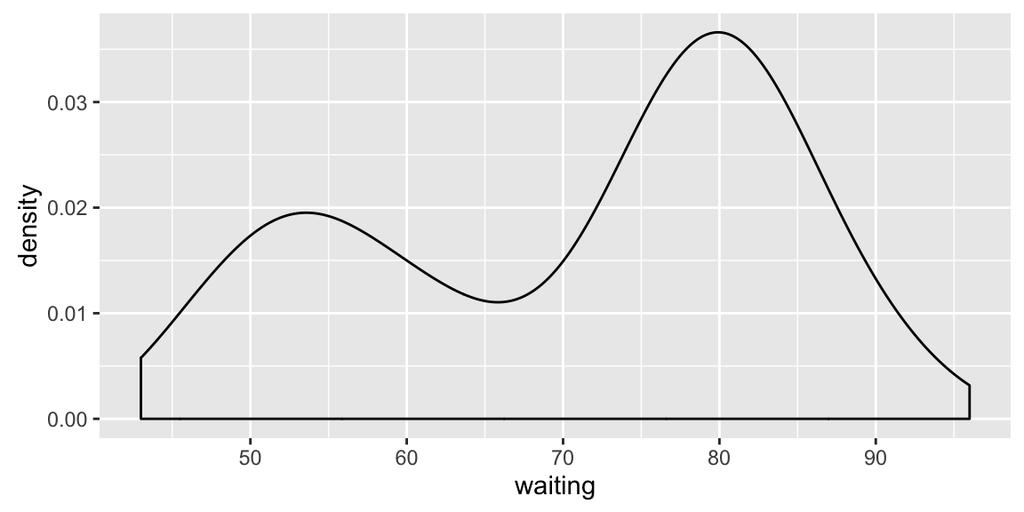

```r
ggplot(faithful, aes(waiting)) + geom_density()
```

Using the density function we can see different basic statistics for the wait times.

```r
density(faithful$waiting)
```

```
##
## Call:
##  density.default(x = faithful$waiting)
##
## Data: faithful$waiting (272 obs.);   Bandwidth 'bw' = 3.988
##
##        x                y
##  Min.   : 31.04   Min.   :5.880e-06
##  1st Qu.: 50.27   1st Qu.:1.949e-03
##  Median : 69.50   Median :1.224e-02
##  Mean   : 69.50   Mean   :1.299e-02
##  3rd Qu.: 88.73   3rd Qu.:1.909e-02
##  Max.   :107.96   Max.   :3.660e-02
```

The density function will also give us x,y values for the distribution.

```r
head(density(faithful$waiting)$y)
```

```
## [1] 8.951193e-06 1.017743e-05 1.152920e-05 1.301184e-05 1.474573e-05
## [6] 1.666005e-05
```

```r
head(density(faithful$waiting)$x)
```

```
## [1] 31.03732 31.18786 31.33840 31.48894 31.63948 31.79002
```

This tells us which value in the distribution is highest on the y axis

```r
which.max(density(faithful$waiting)$y)
```

```
## [1] 326
```

And using that y max value we can find where that lies on the x-axis

```r
density(faithful$waiting)$x[326]
```

```
## [1] 79.96245
```

And add a line to the density plot.

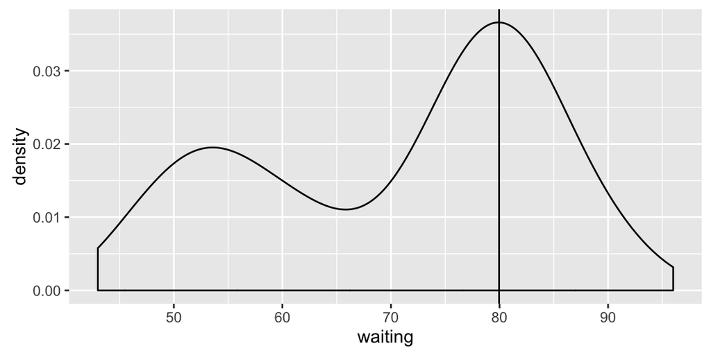

```r
ggplot(faithful, aes(waiting)) + geom_density() + geom_vline(xintercept = density(faithful$waiting)$x[326])
```

# 2 Find The Second Peak

So, quickly, I’m finding the values of x that are less than 65, then finding the peak y value in that range of x values, then plotting the whole thing. You’ll figure it out.

So first this will list all values of the Y axis where the X axis is less than 65

```r
density(faithful$waiting)$y[density(faithful$waiting)$x < 65]
```

```
##   [1] 8.951193e-06 1.017743e-05 1.152920e-05 1.301184e-05 1.474573e-05
##   [6] 1.666005e-05 1.875665e-05 2.112854e-05 2.380540e-05 2.673200e-05
##  [11] 2.994350e-05 3.364019e-05 3.767360e-05 4.205664e-05 4.701996e-05
##  [16] 5.250930e-05 5.846285e-05 6.501305e-05 7.239169e-05 8.037679e-05
##  [21] 8.898839e-05 9.873037e-05 1.093073e-04 1.206897e-04 1.332219e-04
##  [26] 1.470600e-04 1.619169e-04 1.778747e-04 1.957596e-04 2.149124e-04
##  [31] 2.353680e-04 2.578628e-04 2.822526e-04 3.082358e-04 3.361586e-04
##  [36] 3.668419e-04 3.994423e-04 4.340033e-04 4.718905e-04 5.122978e-04
##  [41] 5.550213e-04 6.008712e-04 6.503538e-04 7.025264e-04 7.574535e-04
##  [46] 8.173289e-04 8.802754e-04 9.463413e-04 1.017012e-03 1.092055e-03
##  [51] 1.170589e-03 1.253146e-03 1.341556e-03 1.433803e-03 1.529928e-03
##  [56] 1.632233e-03 1.739318e-03 1.850574e-03 1.967151e-03 2.090021e-03
##  [61] 2.217292e-03 2.348987e-03 2.488201e-03 2.632120e-03 2.780597e-03
##  [66] 2.935406e-03 3.096313e-03 3.261813e-03 3.432322e-03 3.610219e-03
##  [71] 3.792640e-03 3.979568e-03 4.173207e-03 4.372083e-03 4.575265e-03
```

[output cut: 31 more lines]

Then I can find the max y value that is that range of x.

```r
MaxY<- max(density(faithful$waiting)$y[density(faithful$waiting)$x < 65])
```

This will tell me where in the vector of y values this Max Y value appears.

```r
which(density(faithful$waiting)$y == MaxY)
```

```
## [1] 151
```

Then we can use that location to find the complimentary x value and plot it using ggplot

```r
density(faithful$waiting)$x[151]
```

```
## [1] 53.61815
```

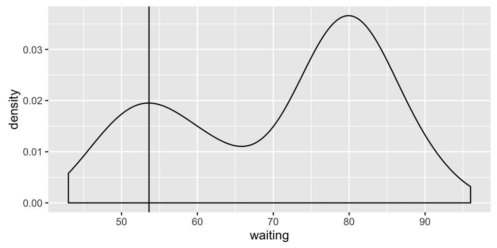

```r
ggplot(faithful, aes(waiting)) + geom_density() + geom_vline(xintercept = density(faithful$waiting)$x[151])
```

# 3 Find The Trough In The Distribution Between The Peaks

Why? Why not.

So first I’ll create the x and y values for this distribution.

```r
DensityFaithfulY <- density(faithful$waiting)$y
DensityFaithfulX <- density(faithful$waiting)$x
```

Now we can isolate the range of values where X is less than 75 and greater than 55.

```r
DensityFaithfulX < 75 & DensityFaithfulX > 55
```

```
##   [1] FALSE FALSE FALSE FALSE FALSE FALSE FALSE FALSE FALSE FALSE FALSE
##  [12] FALSE FALSE FALSE FALSE FALSE FALSE FALSE FALSE FALSE FALSE FALSE
##  [23] FALSE FALSE FALSE FALSE FALSE FALSE FALSE FALSE FALSE FALSE FALSE
##  [34] FALSE FALSE FALSE FALSE FALSE FALSE FALSE FALSE FALSE FALSE FALSE
##  [45] FALSE FALSE FALSE FALSE FALSE FALSE FALSE FALSE FALSE FALSE FALSE
##  [56] FALSE FALSE FALSE FALSE FALSE FALSE FALSE FALSE FALSE FALSE FALSE
##  [67] FALSE FALSE FALSE FALSE FALSE FALSE FALSE FALSE FALSE FALSE FALSE
##  [78] FALSE FALSE FALSE FALSE FALSE FALSE FALSE FALSE FALSE FALSE FALSE
##  [89] FALSE FALSE FALSE FALSE FALSE FALSE FALSE FALSE FALSE FALSE FALSE
## [100] FALSE FALSE FALSE FALSE FALSE FALSE FALSE FALSE FALSE FALSE FALSE
## [111] FALSE FALSE FALSE FALSE FALSE FALSE FALSE FALSE FALSE FALSE FALSE
## [122] FALSE FALSE FALSE FALSE FALSE FALSE FALSE FALSE FALSE FALSE FALSE
## [133] FALSE FALSE FALSE FALSE FALSE FALSE FALSE FALSE FALSE FALSE FALSE
## [144] FALSE FALSE FALSE FALSE FALSE FALSE FALSE FALSE FALSE FALSE FALSE
## [155] FALSE FALSE FALSE FALSE FALSE FALSE  TRUE  TRUE  TRUE  TRUE  TRUE
```

[output cut: 32 more lines]

Get the minimum Y density value.

```r
MinYDensity<- min(DensityFaithfulY[DensityFaithfulX < 75 & DensityFaithfulX > 55])
MinYDensity
```

```
## [1] 0.01104003
```

Find the location in the Y Axis Vector that has this minimum density.

```r
which(DensityFaithfulY == MinYDensity)
```

```
## [1] 232
```

Then identify where on the x axis the minimum y value falls and plot.

```r
DensityFaithfulX[232]
```

```
## [1] 65.8118
```

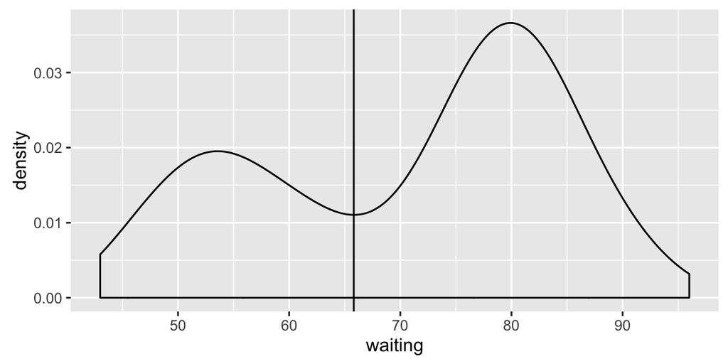

```r
ggplot(faithful, aes(waiting)) + geom_density() + geom_vline(xintercept = density(faithful$waiting)$x[232])
```

# 4 Density Peak Function

We can also use this function to find the x and y axis for the peak of the density.

```r
densMode <- function(x){
    td <- density(x)
    maxDens <- which.max(td$y)
    list(x=td$x[maxDens], y=td$y[maxDens])
}

densMode(faithful$waiting)
```

```
## $x
## [1] 79.96245
##
## $y
## [1] 0.03660056
```

There’s also this which returns x values.

```r
peakx <- DensityFaithfulX[which(diff(sign(diff(DensityFaithfulY)))==-2)]
peakx
```

```
## [1] 53.46761 79.81191
```

```r
minx <- DensityFaithfulX[which(diff(sign(diff(DensityFaithfulY)))==2)]
minx
```

```
## [1] 65.66126
```

It’s close but not quite right. It gives vector numbers of 150 and 325 for the peaks but the actual numbers are 151 and 326.

```r
which(diff(sign(diff(DensityFaithfulY)))==-2)
```

```
## [1] 150 325
```

```r
which.max(density(faithful$waiting)$y)
```

```
## [1] 326
```

```r
which(density(faithful$waiting)$y == MaxY)
```

```
## [1] 151
```